# COPDGene/DECAMP Radiologic Clustering Project - Results Version 2

Samuel Ash

2018-12-14

# 1 Overview

This document describes the results of the imaging clusters from COPDGene based on prior DECAMP clustering. This includes: 1) Clustering of COPDGene and DECAMP 2) Radiographic characteristics of clusters in COPDGene and DECAMP 3) Baseline clinical characteristics of overall cohort (Table 1) and by cluster in COPDGene 4) Progression (FEV1, exercise capacity, emphysema) by cluster in COPDGene including plots (rates) and mixed effect models 5) Mortality in COPDGene by cluster 6) Exacerbation rates in COPDGene by cluster 7) Biomarkers in COPDGene by cluster

Additional Notes: 1) r code is available for reference by clicking the code folding buttons on the right. 2) Cluster labeling updated to reflect manuscript 3) Table 1 modified to incorporate cluster information

# 2 Load Libraries and Data

## 2.1 Libraries

```r
library(devtools)
library(tidyverse)
library(janitor)
library(cowplot)
library(survival)
library(survminer)
library(readxl)
library(ggfortify)
library(ggpubr)
library(rmarkdown)
library(Hmisc)
library(Gmisc)
library(lme4)
library(fields)
library(languageR)
library(lmerTest)
library(cluster)
library(factoextra)
library(mclust)
library(NbClust)
library(pscl)
library(tableone)
library(labelled)
library(knitr)
library(rmarkdown)
library(kableExtra)
library(scales)
library(broman)
```

## 2.2 Data

DECAMP datasets used include: 1) DECAMP imaging dataset from October 9, 2018

```r
## 02 Initial Import and Cleaning of COPDGene Data ##
## edited 2018_08_08

setwd('/Users/sya2/OneDrive - Partners HealthCare/research/imaging/genetics/clustering/imaging_clusters')

#### general COPDGene database ####
copd <- read_delim("data/raw_data/COPDGene_P1P2_All_Visit_09OCT17.txt",
                   "\t", escape_double = FALSE, trim_ws = TRUE)
# clean variable names and remove columns and rows with all NA
copd_clean <- clean_names(copd) %>%
  rename(dlco_pp=dlc_opp,
         tlc_pp_race_adjusted=tl_cpp_race_adjusted,
         fvcpp_utah=fv_cpp_utah,
         dlco_raw=d_lco_raw) %>%
  remove_empty()
## calculate change variables ##
# remove subset of variables that we are interested in their change over time
copd_change = copd_clean %>% select(sid,visitnum,height_cm,weight_kg,
                                     distwalked,sgrq_score_total,dlco_pp, dlco_raw,
                                     tlc_pp_race_adjusted,fev1pp_utah,fvcpp_utah,
                                     fev1_fvc_utah,pct_emph_thirona,tlc_thirona,
                                     pct_gas_trap_thirona,awt_seg_thirona,
                                     fev1_utah,fvc_utah)
# spread to wide format
copd_change_wide = copd_change %>%
  tidyr::gather_(key="variable", value="value",
                 c("height_cm",
                   "weight_kg",
                   "distwalked",
                   "sgrq_score_total",
                   "dlco_pp",
                   "dlco_raw",
                   "tlc_pp_race_adjusted",
                   "fev1pp_utah",
                   "fvcpp_utah",
                   "fev1_fvc_utah",
                   "pct_emph_thirona",
                   "tlc_thirona",
                   "pct_gas_trap_thirona",
                   "awt_seg_thirona",
                   "fev1_utah",
                   "fvc_utah"
                   )) %>%
  tidyr::unite("time_by_variable", variable, visitnum, remove=T) %>%
  tidyr::spread(key=time_by_variable, value=value)
# calculate change between two variables
copd_delta = copd_change_wide %>%
  mutate(awt_seg_thirona_delta = awt_seg_thirona_2 - awt_seg_thirona_1,
         distwalked_delta = distwalked_2 - distwalked_1,
         dlco_pp_delta = dlco_pp_2 - dlco_pp_1,
         dlco_raw_delta = dlco_pp_2 - dlco_raw_1,
         fev1_fvc_utah_delta = fev1_fvc_utah_2 - fev1_fvc_utah_1,
         fev1_utah_delta = fev1_utah_2 - fev1_utah_1,
         fev1pp_utah_delta = fev1pp_utah_2 - fev1pp_utah_1,
         fvc_utah_delta = fvc_utah_2 - fvc_utah_1,
         fvcpp_utah_delta = fvcpp_utah_2 - fvcpp_utah_1,
         height_cm_delta = height_cm_2 - height_cm_1,
         pct_emph_thirona_delta = pct_emph_thirona_2 - pct_emph_thirona_1,
         pct_gas_trap_thirona_delta = pct_gas_trap_thirona_2 - pct_gas_trap_thirona_1,
         sgrq_score_total_delta = sgrq_score_total_2 - sgrq_score_total_1,
         tlc_pp_race_adjusted_delta = tlc_pp_race_adjusted_2 - tlc_pp_race_adjusted_1,
         tlc_thirona_delta = tlc_thirona_2 - tlc_thirona_1,
         weight_kg_delta = weight_kg_2 - weight_kg_1) %>%
  select(sid,awt_seg_thirona_delta,distwalked_delta,dlco_pp_delta,
         fev1_fvc_utah_delta,fev1_utah_delta,fev1pp_utah_delta,fvc_utah_delta,fvcpp_utah_delta,
         height_cm_delta,pct_emph_thirona_delta,pct_gas_trap_thirona_delta,sgrq_score_total_delta,
         tlc_pp_race_adjusted_delta,weight_kg_delta)
# extract time between visits and copdgene calculated change variables
copd_time = copd_clean %>% select(sid,days_ct1_ct2,days_phase1_phase2,
                                   change_tlc_thirona, change_pct_emph_thirona, change_pct_gas_trap_thirona,
                                   change_p1_p2_fev1_ml,change_p1_p2_fev1pp) %>%
  filter(days_phase1_phase2>0)
# remove visit 2 data and finalgold -2 from base dataset
copd_base = copd_clean %>% filter(visitnum==1) %>% filter(final_gold > -2) %>% select(-visitnum)
# merge delta variable data with baseline data
copd_pre = inner_join(copd_base,copd_delta)
# add time variables and remove variables that are all NA
copd_base_full = left_join(copd_pre,copd_time,by="sid") %>% remove_empty()
# add prior exacerbation binary variable
copd_base_full = copd_base_full %>% mutate(priorexacerbation = ifelse(exacerbation_frequency > 0, 1, 0))

### mortality and LFU dataset addition to baseline dataset ###
# import datasets
copd_mort <- read_delim("data/raw_data/COPDGene_Mortality_Surv_2016dec.txt",
                                                          "\t", escape_double = FALSE, col_types = cols(DOD_merged = col_date(format = "%m/%d/%Y"),
                                                                                                        Phase1_date = col_date(format = "%m/%d/%Y"),
                                                                                                        date_SSDI_confirmed = col_date(format = "%m/%d/%Y"),
                                                                                                        date_last_SSDI_search = col_date(format = "%m/%d/%Y"),
                                                                                                        days_followed = col_number(), last_LFU_survey_date = col_date(format = "%m/%d/%Y")),
                                                          trim_ws = TRUE)
copd_lfu <- read_delim("data/raw_data/LFU_SidLevel_w_Comorbid_31JUL17.txt",
                       "\t", escape_double = FALSE, col_types = cols(
                                                                     reportedSmokingStatusString = col_skip()),
                       trim_ws = TRUE)
# merge datasets
copd_clinical_full_1 = left_join(copd_base_full,copd_mort)
copd_clinical_full = left_join(copd_clinical_full_1,copd_lfu) %>% remove_empty()

### local histogram data using third training set ###
copd_lh = read_excel("data/raw_data/LHsubtypes_2016_09_21_v2.xlsx") %>% clean_names()
copd_pre1 = left_join(copd_clinical_full,copd_lh) %>% remove_empty()

### body composition from manual measurements ###
copd_body <- Body_Composition_COPDGene <- read_csv("data/raw_data/Body Composition COPDGene.csv")
copd_pre2 <- left_join(copd_pre1,copd_body) %>% remove_empty()

### biomarker data from Russ Bowler (RBM only) ###
copd_bio <- read_csv("data/raw_data/COPDGene_Bowler_RBM_raw.csv") %>% clean_names() %>% remove_empty()
copd_full <- left_join(copd_pre2,copd_bio)

#############additional data manipulation################
# rename gender
copd_full = copd_full %>% mutate(sex = ifelse(gender==2,"female","male"))
# normalize imaging variables
copd_full = copd_full %>% mutate(percent_ild_z = percent_ild, percent_emphysema_z = percent_emphysema,
                                 percent_normal_z = percent_normal, awt_seg_thirona_z = awt_seg_thirona, PMA_z = PMA) %>%
  mutate_at(scale,.vars = vars(percent_ild_z, percent_emphysema_z, percent_normal_z, awt_seg_thirona_z, PMA_z))

### dataset with no missing imaging data for clustering ###
copd_full_imaging = copd_full %>% filter(!is.na(percent_ild), !is.na(percent_emphysema), !is.na(awt_seg_thirona), !is.na(PMA))

############# manipulate COPDGene round 2 local histogram data ##################################################
### clean round 2 local histogram data from COPDGene and create
## 1) wide format file with delta variables then will then merge with baseline file in wide format for rate calculations
## 2) file with visit number two that can then be merged (in addition to baseline LH data) with base file to create long format file for longitudinal anlysis using mixed methods

### import COPDGene Round 2 LH dataset ###
COPDGene_LH_2_raw <- read_csv("data/raw_data/COPDGene2_localHistogram_parenchymaPhenotypes_20180319_wideFormat.csv")
COPDGene_LH_2_pre1 <- clean_names(COPDGene_LH_2_raw)

###################################### file with summary whole lung LH values ######################################
COPDGene_LH_2_summary_whole_pre1 <- COPDGene_LH_2_pre1 %>% select(starts_with("whole")) %>% select(-contains("wild")) %>% select(contains("type_frac"))
COPDGene_LH_2_CID <- COPDGene_LH_2_pre1 %>% select(contains("cid")) %>% mutate(sid=str_sub(cid,start=1L,end=6L))
COPDGene_LH_2_summary_whole_pre2 <- bind_cols(COPDGene_LH_2_summary_whole_pre1,COPDGene_LH_2_CID)

COPDGene_LH_2_summary_whole <- COPDGene_LH_2_summary_whole_pre2 %>%
  mutate(percent_normal = whole_lung_normal_parenchyma_type_frac*100) %>%
  mutate(percent_emphysema = (whole_lung_centrilobular_emphysema_type_frac + whole_lung_emphysematous_type_frac)*100) %>%
  mutate(percent_ild = (whole_lung_reticular_type_frac + whole_lung_subpleural_line_type_frac + whole_lung_ground_glass_type_frac +
           whole_lung_linear_scar_type_frac + whole_lung_centrilobular_nodule_type_frac + whole_lung_cyst_type_frac + whole_lung_nodular_type_frac +
           whole_lung_nodule_type_frac + whole_lung_bronchiectatic_airway_type_frac + whole_lung_honeycombing_type_frac)*100) %>%
  select(cid, sid, percent_normal, percent_emphysema, percent_ild)

################################################################################DECAMP#############################################################
decamp_pre1 <- read_excel("data/raw_data/DECAMP clustering imaging variables.xlsx")
decamp_pre2 <- decamp_pre1 %>% mutate(percent_ild_z = Percent_ILA, percent_emphysema_z = Percent_Emphysema,
                                  percent_normal_z = Percent_Normal, awt_seg_thirona_z = WallThickness, PMA_z = Standard_PMA) %>%
  mutate_at(scale,.vars = vars(percent_ild_z, percent_emphysema_z, percent_normal_z, awt_seg_thirona_z, PMA_z)) %>%
  select(Case,percent_ild_z,percent_emphysema_z,
         percent_normal_z,PMA_z,awt_seg_thirona_z)
```

# 3 Analysis

## 3.1 Clustering

Methods notes: Clustering was performed in both the DECAMP and COPDGene cohorts separately using the k-means method based on the following computed tomography (CT) imaging based measurements: the percentage of lung occupied by emphysema, the percentage of lung occupied by interstitial changes, the percentage of lung occupied by normal tissue, third generation airway wall thickness and the pectoralis muscle area, all of which were centered and scaled using their mean and standard deviation.

```r
set.seed(9)
copd_cluster_pre = copd_full_imaging %>% select(sid,percent_ild_z,percent_emphysema_z,
                                                percent_normal_z,PMA_z,awt_seg_thirona_z) # dataset with just SID and normalized imaging variables
km = kmeans(copd_cluster_pre[,2:6],3)

copd_full_imaging$cluster <- as.factor(km$cluster) # add initial cluster label to dataset of people with complete imaging data
copd_full_imaging = copd_full_imaging %>% mutate(cluster_decamp = ifelse(cluster=="1","Emphysema Predominant",
                                                                         ifelse(cluster=="2","Interstitial Predominant",
                                                                                "Preserved")))

copd_imaging_cluster <- copd_cluster_pre
copd_imaging_cluster$cluster <- as.factor(km$cluster) # add initial cluster label to imaging data only
copd_imaging_cluster <- copd_imaging_cluster %>% mutate(cluster_decamp = ifelse(cluster=="1","Emphysema Predominant",
                                                                         ifelse(cluster=="2","Interstitial Predominant",
                                                                                "Preserved"))) %>%
  mutate(Cohort="COPDGene") %>% select(-cluster)
```

```r
############################### wide format file with rate of change in LH measures #########
# note run after clustering assignement in order to include cluster assignment
COPDGene_LH_2_whole_2 <- COPDGene_LH_2_summary_whole %>% rename(percent_normal_2 = percent_normal, percent_emphysema_2 = percent_emphysema, percent_ild_2 = percent_ild)
copd_full_imaging_2 <- inner_join(copd_full_imaging, COPDGene_LH_2_whole_2) %>%
  filter(!is.na(percent_ild_2), !is.na(percent_emphysema_2)) %>%
  mutate(percent_normal_delta = percent_normal_2 - percent_normal, percent_emphysema_delta = percent_emphysema_2 - percent_emphysema, percent_ild_delta = percent_ild_2 - percent_ild) %>%
  mutate(percent_normal_rate = percent_normal_delta/(days_ct1_ct2.y/365), percent_emphysema_rate = percent_emphysema_delta/(days_ct1_ct2.y/365), percent_ild_rate = percent_ild_delta/(days_ct1_ct2.y/365))

############################ merge with long format base dataset ###########
COPDGene_LH_2_whole_3 <- COPDGene_LH_2_summary_whole %>% mutate(visitnum=2) %>% select(-cid)
copd_lh_base <- copd_lh %>% mutate(visitnum=1)
copd_lh_both <- rbind(copd_lh_base,COPDGene_LH_2_whole_3)

copd_cluster_assignments <- copd_full_imaging %>% select(sid,cluster_decamp,days_ct1_ct2.y)

copd_long <- left_join(copd_lh_both,copd_cluster_assignments) %>% filter(!is.na(cluster_decamp)) %>%
  mutate(days=ifelse(visitnum==2,days_ct1_ct2.y,0)) %>%
  filter(!is.na(days)) %>% select(-days_ct1_ct2.y) %>%
  mutate(years=days/365)

## merge long format imaging dataset with long format baseline dataset
copd_clean_pre <- copd_clean %>% select(sid,same_scanner_model,visitnum) %>%
  spread(visitnum,same_scanner_model)
names(copd_clean_pre)[names(copd_clean_pre)=='1'] <- "visit_1"
names(copd_clean_pre)[names(copd_clean_pre)=='2'] <- "visit_2"
copd_clean_pre2 <- copd_clean_pre %>% mutate(visit_1 = visit_2) %>% drop_na(visit_1) %>%
  gather(visitnum_char,same_scanner_model_full,visit_1:visit_2) %>% mutate(visitnum=ifelse(visitnum_char=="visit_1",1,2))

copd_long_full <- left_join(copd_long, copd_clean)

copd_long_full_same_scan <- left_join(copd_long_full,copd_clean_pre2) %>% filter(same_scanner_model_full == 1)

copd_long_clinical <- left_join(copd_clean,copd_cluster_assignments) %>% filter(!is.na(cluster_decamp)) %>%
  mutate(days=ifelse(visitnum==2,days_ct1_ct2.y,0)) %>%
  filter(!is.na(days)) %>% select(-days_ct1_ct2.y) %>%
  mutate(years=days/365)
```

```r
set.seed(9)
km = kmeans(decamp_pre2[,2:6],3)
decamp_clusters <- decamp_pre2
decamp_clusters$cluster <- as.factor(km$cluster) # add initial cluster label to dataset of people with complete imaging data
decamp_clusters = decamp_clusters %>% mutate(cluster_decamp = ifelse(cluster=="1","Preserved",
                                                                     ifelse(cluster=="2","Interstitial Predominant",
                                                                            "Emphysema Predominant")))
decamp_imaging_clusters <- decamp_clusters %>% mutate(Cohort="DECAMP") %>% mutate(sid=Case) %>% select(-Case, -cluster)
decamp_full_imaging_cluster <- left_join(decamp_pre1,decamp_clusters) %>% mutate(PMA_10 = Standard_PMA/100)
```

### 3.1.1 Number of clusters:

Methods notes: The optimal number of clusters was selected by evaluating the average silhouette width and total within sums of squares for 1-10 clusters in the COPDGene cohort. Based on these results k=3 was selected.

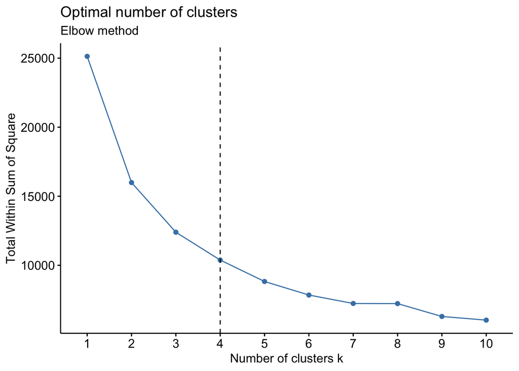

```r
# optimal number of clusters using COPDGene data
set.seed(9)
# Elbow method
df <- copd_cluster_pre[,2:6]
fviz_nbclust(df, kmeans, method = "wss") +
  geom_vline(xintercept = 4, linetype = 2)+
  labs(subtitle = "Elbow method")
```

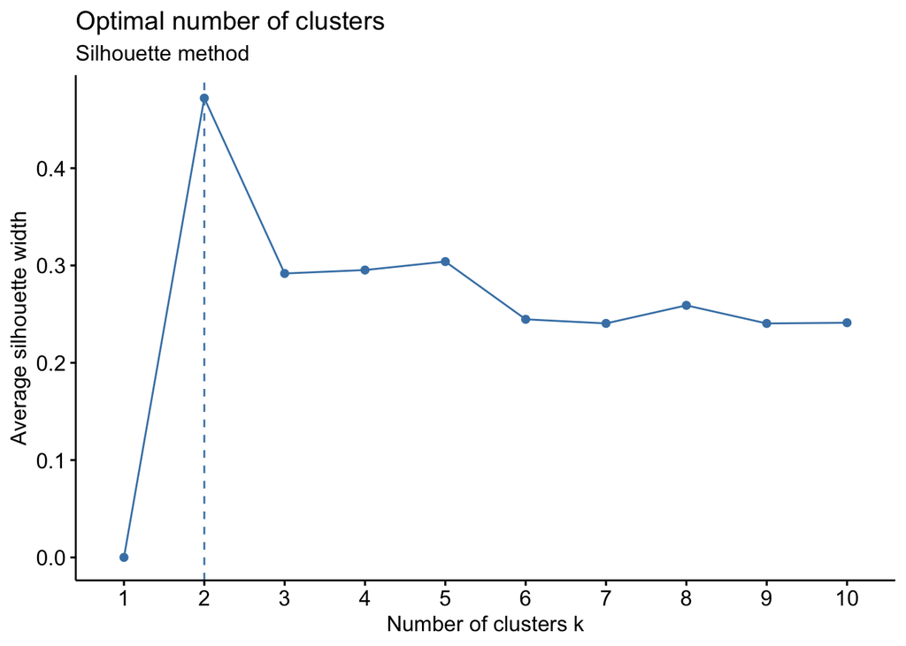

```r
# Silhouette method
fviz_nbclust(df, kmeans, method = "silhouette")+
  labs(subtitle = "Silhouette method")
```

### 3.1.2 Cluster appearance:

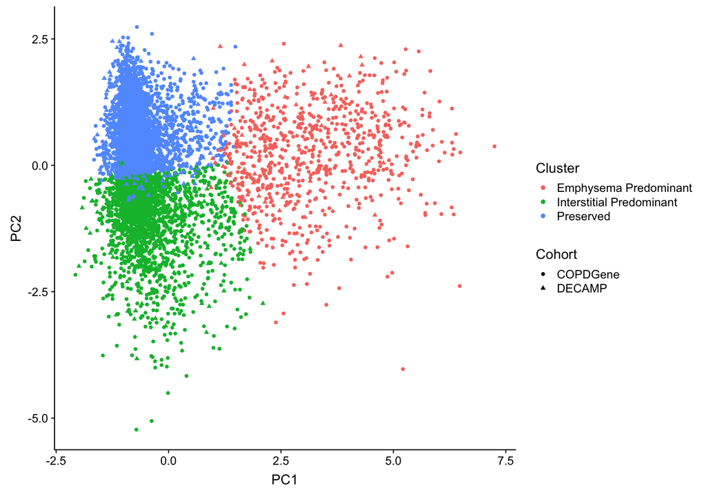

```r
# conduct PCA on training dataset (COPDGene)
pc <- c(1,2)
pca <- prcomp(copd_imaging_cluster[,2:6], retx=TRUE)
expl.var <- round(pca$sdev^2/sum(pca$sdev^2)*100) # percent explained variance
copd_imaging_cluster_pca <- cbind(copd_imaging_cluster,pca$x[,pc]) %>% select(sid,PC1,PC2,Cohort,cluster_decamp)

# prediction of PCs for validation dataset (DECAMP)
pred <- predict(pca, newdata=decamp_imaging_clusters[,1:5])
decamp_imaging_cluster_pca <- cbind(decamp_imaging_clusters,pred[,pc]) %>% select(sid,PC1,PC2,Cohort,cluster_decamp)

###Plot result
copd_decamp_imaging_cluster_pca <- full_join(copd_imaging_cluster_pca,decamp_imaging_cluster_pca)
copd_decamp_imaging_cluster_pca <- copd_decamp_imaging_cluster_pca %>% mutate(Cluster=cluster_decamp)

copd_decamp_imaging_cluster_pca_plot <- ggplot(copd_decamp_imaging_cluster_pca, aes(x=PC1,y=PC2,colour=Cluster,shape=Cohort)) +
  geom_point()

copd_decamp_imaging_cluster_pca_plot
```

## 3.2 Comparison of clusters with regard to baseline imaging characteristcs:

Methods notes: Global comparisons between means made using ANOVA. Pairwise comparisons made using t-tests.

### 3.2.1 COPDGene

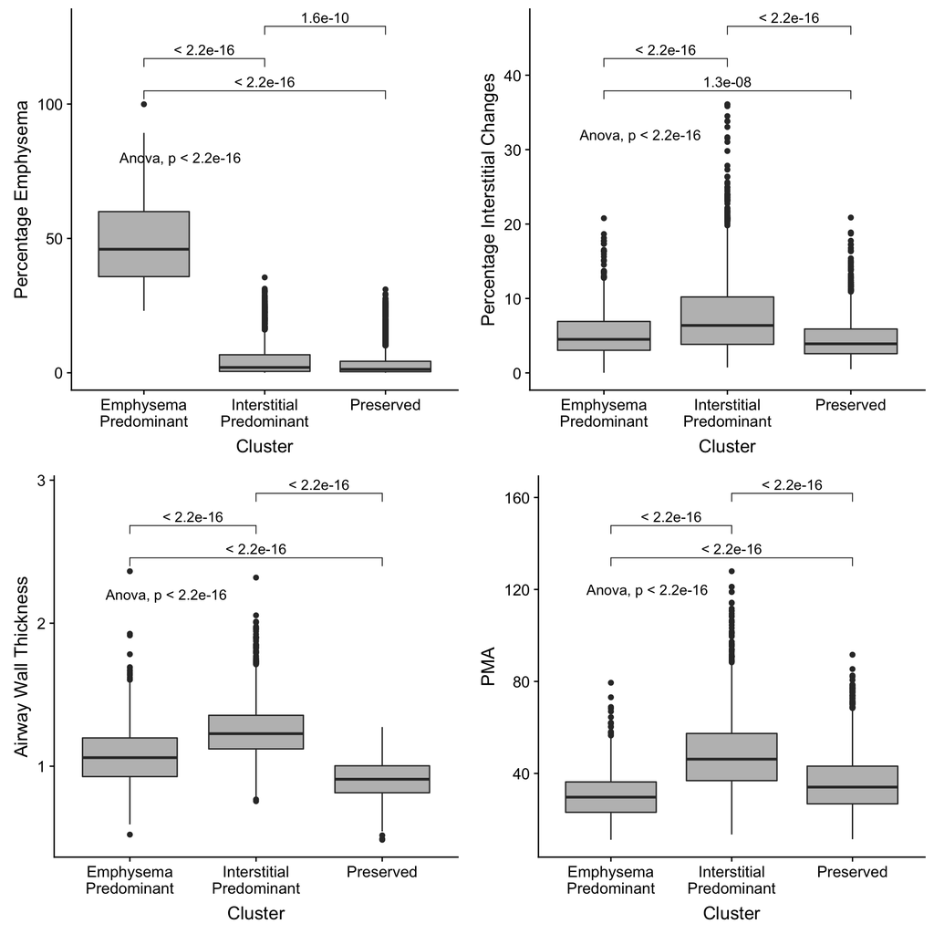

```r
cluster_comparisons <- list( c("Preserved", "Emphysema Predominant"),
                             c("Emphysema Predominant", "Interstitial Predominant"),
                             c("Preserved", "Interstitial Predominant") )

copd_emph_cluster_plot =  ggplot(copd_full_imaging, aes(cluster_decamp,percent_emphysema)) +
  geom_boxplot(fill="gray") +
  ylab("Percentage Emphysema") +
  xlab("Cluster") +
  stat_compare_means(comparisons = cluster_comparisons) + # Add pairwise comparisons p-value
  stat_compare_means(label.y = 80, method="anova") +
  scale_x_discrete(labels=wrap_format(10))
copd_ild_cluster_plot = ggplot(copd_full_imaging, aes(cluster_decamp,percent_ild)) +
  geom_boxplot(fill="gray") +
  ylab("Percentage Interstitial Changes") +
  xlab("Cluster") +
  stat_compare_means(comparisons = cluster_comparisons) + # Add pairwise comparisons p-value
  stat_compare_means(label.y = 32, method="anova") +
  scale_x_discrete(labels=wrap_format(10))
copd_awt_cluster_plot = ggplot(copd_full_imaging, aes(cluster_decamp,awt_seg_thirona)) +
  geom_boxplot(fill="gray") +
  ylab("Airway Wall Thickness") +
  xlab("Cluster") +
  stat_compare_means(comparisons = cluster_comparisons) + # Add pairwise comparisons p-value
  stat_compare_means(label.y = 2.2, method="anova") +
  scale_x_discrete(labels=wrap_format(10))
copd_pma_cluster_plot = ggplot(copd_full_imaging, aes(cluster_decamp,PMA)) +
  geom_boxplot(fill="gray") +
  ylab("PMA") +
  xlab("Cluster") +
  stat_compare_means(comparisons = cluster_comparisons) + # Add pairwise comparisons p-value
  stat_compare_means(label.y = 120, method="anova") +
  scale_x_discrete(labels=wrap_format(10))

plot_grid(copd_emph_cluster_plot,copd_ild_cluster_plot,copd_awt_cluster_plot,copd_pma_cluster_plot, ncol=2)
```

### 3.2.2 DECAMP

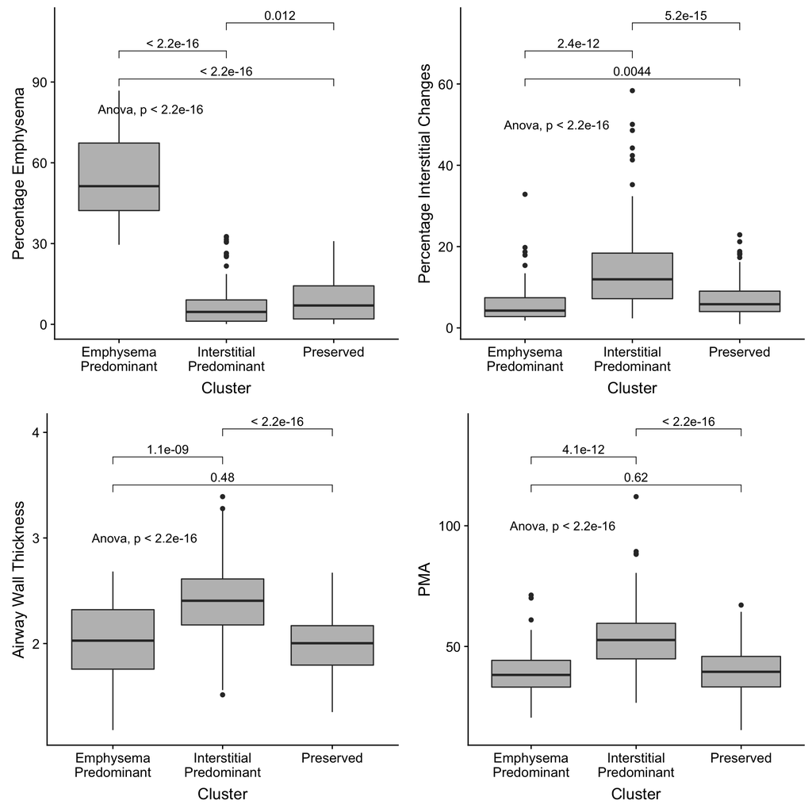

```r
decamp_emph_cluster_plot =  ggplot(decamp_full_imaging_cluster, aes(cluster_decamp,Percent_Emphysema)) +
  geom_boxplot(fill="gray") +
  ylab("Percentage Emphysema") +
  xlab("Cluster") +
  stat_compare_means(comparisons = cluster_comparisons) + # Add pairwise comparisons p-value
  stat_compare_means(label.y = 80, method="anova") +
  scale_x_discrete(labels=wrap_format(10))
decamp_ild_cluster_plot = ggplot(decamp_full_imaging_cluster, aes(cluster_decamp,Percent_ILA)) +
  geom_boxplot(fill="gray") +
  ylab("Percentage Interstitial Changes") +
  xlab("Cluster") +
  stat_compare_means(comparisons = cluster_comparisons) + # Add pairwise comparisons p-value
  stat_compare_means(label.y = 50, method="anova") +
  scale_x_discrete(labels=wrap_format(10))
decamp_awt_cluster_plot = ggplot(decamp_full_imaging_cluster, aes(cluster_decamp,WallThickness)) +
  geom_boxplot(fill="gray") +
  ylab("Airway Wall Thickness") +
  xlab("Cluster") +
  stat_compare_means(comparisons = cluster_comparisons) + # Add pairwise comparisons p-value
  stat_compare_means(label.y = 3, method="anova") +
  scale_x_discrete(labels=wrap_format(10))
decamp_pma_cluster_plot = ggplot(decamp_full_imaging_cluster, aes(cluster_decamp,PMA_10)) +
  geom_boxplot(fill="gray") +
  ylab("PMA") +
  xlab("Cluster") +
  stat_compare_means(comparisons = cluster_comparisons) + # Add pairwise comparisons p-value
  stat_compare_means(label.y = 100, method="anova") +
  scale_x_discrete(labels=wrap_format(10))


plot_grid(decamp_emph_cluster_plot,decamp_ild_cluster_plot,decamp_awt_cluster_plot,decamp_pma_cluster_plot, ncol=2)
```

## 3.3 Baseline clinical characteristics in COPDGene and DECAMP

### 3.3.1 Table 1:

```r
# format COPDGene
copd_full_imaging <- copd_full_imaging %>%
  mutate(sex_f=factor(sex,levels=c("female","male"),labels=c("Female","Male")),
         race_f=factor(race,levels=c(1,2),labels=c("White","Black")),
         smok_cig_now_f=factor(smok_cig_now,levels=c(0,1),labels=c("Former Smoker","Current Smoker")),
         Cluster=cluster_decamp)

## import table 1 data from DECAMP and rename variables to make COPDGene


## select table 1 variables from COPDGene ##
copd_table_1_vars <- c("age_enroll","bmi","fev1pp_utah","percent_ild","percent_emphysema","PMA","awt_seg_thirona","sex_f","race_f","smok_cig_now_f")

## label table 1 variables ##
copd_table_1_var_labels <- list(age_enroll="Age in Years",
                                 bmi="Body Mass Index (kg/m2)",
                                 fev1pp_utah="FEV1 (Percent Predicted)",
                                 percent_ild="Interstitial Features (Percent Lung)",
                                 percent_emphysema="Emphysema (Percent Lung)",
                                 PMA="Pectoralis Muscle Area (cm2)",
                                 awt_seg_thirona="Airway Wall Thickness (mm)",
                                 race_f="Race",
                                 sex_f="Gender",
                                 smok_cig_now_f="Smoking Status",
                                cluster_decamp="Cluster")
labelled::var_label(copd_full_imaging) <- copd_table_1_var_labels

table_one <- print(CreateTableOne(vars=copd_table_1_vars,strata="Cluster",data=copd_full_imaging),varLabels=TRUE,test=FALSE,pval=FALSE,printToggle = FALSE)
kable(table_one) %>%
  add_header_above(c(" " = 1, "Cluster" = 3)) %>%
  kable_styling(bootstrap_options = "striped", full_width = T)
```

|  | Cluster Emphysema Predominant | Cluster Interstitial Predominant | Cluster Preserved |
| --- | --- | --- | --- |
| n | 741 | 1920 | 2612 |
| Age in Years (mean (sd)) | 65.56 (7.70) | 59.91 (9.09) | 60.27 (8.64) |
| Body Mass Index (kg/m2) (mean (sd)) | 25.47 (5.00) | 31.00 (6.23) | 27.88 (5.53) |
| FEV1 (Percent Predicted) (mean (sd)) | 40.65 (19.91) | 73.28 (22.10) | 86.53 (20.10) |
| Interstitial Features (Percent Lung) (mean (sd)) | 5.34 (3.27) | 7.81 (5.36) | 4.60 (2.73) |
| Emphysema (Percent Lung) (mean (sd)) | 48.62 (15.23) | 4.93 (6.59) | 3.67 (5.43) |
| Pectoralis Muscle Area (cm2) (mean (sd)) | 30.96 (10.64) | 48.87 (16.67) | 36.04 (12.15) |
| Airway Wall Thickness (mm) (mean (sd)) | 1.08 (0.22) | 1.25 (0.19) | 0.91 (0.13) |
| Gender = Male (%) | 432 (58.3) | 1379 (71.8) | 971 (37.2) |
| Race = Black (%) | 121 (16.3) | 678 (35.3) | 588 (22.5) |
| Smoking Status = Current Smoker (%) | 154 (20.8) | 1089 (56.7) | 1141 (43.7) |

### 3.3.2 Comparisons based on clusters:

Methods notes: Global comparisons between means made using ANOVA. Pairwise comparisons made using t-tests.

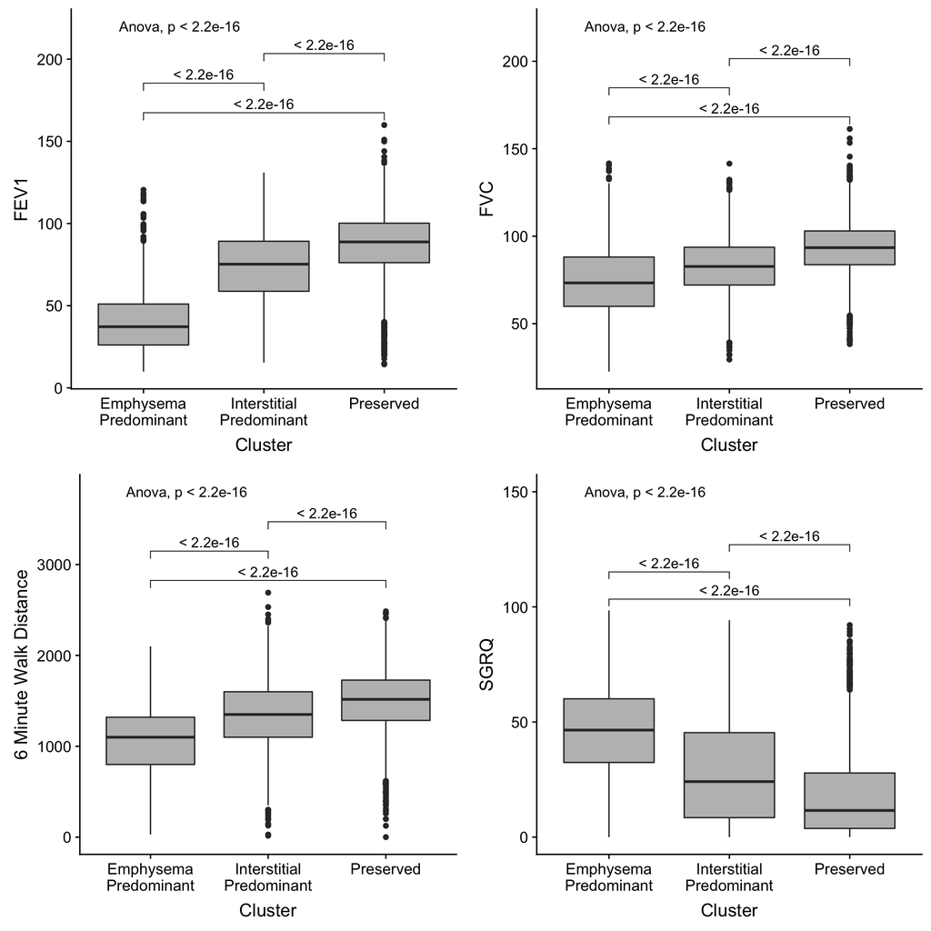

```r
fev1_cluster_plot =  ggplot(copd_full_imaging, aes(cluster_decamp,fev1pp_utah)) +
  geom_boxplot(fill="gray") +
  ylab("FEV1") +
  xlab("Cluster") +
  stat_compare_means(comparisons = cluster_comparisons) + # Add pairwise comparisons p-value
  stat_compare_means(label.y = 220, method="anova") +
  scale_x_discrete(labels=wrap_format(10))
fvc_cluster_plot = ggplot(copd_full_imaging, aes(cluster_decamp,fvcpp_utah)) +
  geom_boxplot(fill="gray") +
  ylab("FVC") +
  xlab("Cluster") +
  stat_compare_means(comparisons = cluster_comparisons) + # Add pairwise comparisons p-value
  stat_compare_means(label.y = 220, method="anova") +
  scale_x_discrete(labels=wrap_format(10))
sixmin_cluster_plot = ggplot(copd_full_imaging, aes(cluster_decamp,distwalked)) +
  geom_boxplot(fill="gray") +
  ylab("6 Minute Walk Distance") +
  xlab("Cluster") +
  stat_compare_means(comparisons = cluster_comparisons) + # Add pairwise comparisons p-value
  stat_compare_means(label.y = 3800, method="anova") +
  scale_x_discrete(labels=wrap_format(10))
sgrq_cluster_plot = ggplot(copd_full_imaging, aes(cluster_decamp,sgrq_score_total)) +
  geom_boxplot(fill="gray") +
  ylab("SGRQ") +
  xlab("Cluster") +
  stat_compare_means(comparisons = cluster_comparisons) + # Add pairwise comparisons p-value
  stat_compare_means(label.y = 150, method="anova") +
  scale_x_discrete(labels=wrap_format(10))

plot_grid(fev1_cluster_plot,fvc_cluster_plot,sixmin_cluster_plot,sgrq_cluster_plot, ncol=2)
```

## 3.4 Comparison of COPDGene clusters with regard to progression over 5 years of follow up:

### 3.4.1 Clinical progression

```r
myround2 <- function(x, digits = 3){
  if (x < 10^-digits) return(paste('<', 10^-digits))
  paste('=', myround(x, digits))
}
```

```r
copd_long_clinical$cluster_decamp_f <- factor(copd_long_clinical$cluster_decamp) # setup comparisons
contrasts(copd_long_clinical$cluster_decamp_f) <- contr.treatment(3, base=3) # setup comparisons

fev1_prog_uni_fit <- lmer(fev1pp_utah ~ years + cluster_decamp_f*years + (years||sid),data=copd_long_clinical)
#summary(fev1_prog_uni_fit)[[10]]
#confint(fev1_prog_uni_fit)

distwalked_prog_uni_fit <- lmer(distwalked ~ years + cluster_decamp_f*years + (years||sid),data=copd_long_clinical)
#summary(distwalked_prog_uni_fit)[[10]]
#confint(distwalked_prog_uni_fit)
```

Mixed effects model using random intercepts and slopes:

1. With regard to FEV1 progression. The results are expressed for percent predicted FEV1. Briefly, over the course of follow up, those individuals in the emphysema predominant cluster lost 0.66% more FEV1% (absolute change) (Confidence Interval: -0.87% to -0.44%) per year than those in the reference (resiliant) group (p< 0.001). No such effect was seen in the interstitial predominant group (p= 0.703).
2. With regard to six minute walk distance. The results are expressed in feet. Briefly, over the course of follow up, those individuals in the emphysema predominant cluster lost 15.9 feet more per year in their six minute walk distance (Confidence Interval: -23.4 to -8.5) than those in the reference group (p< 0.001) and those in the interstitial predominant group lost 6.2 feet more per year in their six minute walk distance (Confidence Interval: -10.62 to -1.72) than those in the reference group (p= 0.007).

### 3.4.2 Radiographic (emphysema) progression in COPDGene:

```r
copd_long_full_same_scan$cluster_decamp_f <- factor(copd_long_full_same_scan$cluster_decamp) # setup comparisons
contrasts(copd_long_full_same_scan$cluster_decamp_f) <- contr.treatment(3, base=3) # setup comparisons

emphysema_prog_uni_fit <- lmer(percent_emphysema ~ years + cluster_decamp_f*years + (years||sid),data=copd_long_full_same_scan)
#summary(emphysema_prog_uni_fit)[[10]]
#confint(emphysema_prog_uni_fit)
```

Mixed effects model using random intercepts and slopes. Methods notes: Note that this analysis is limited to those individuals who were scanned using the same scanner make and model for both visits (n=2354)

Results notes: The results are expressed in percentage of lung occupied by emphysema. Briefly, over the course of follow up, those individuals in the emphysema predominant cluster gained 0.3% more emphysema (absolute change) (Confidence Interval: 0.13% to 0.47%) than those in the reference group (p< 0.001) and those in the interstitial predominant group gained 0.13% more emphysema (Confidence Interval: 0.03 to 0.23) than those in the reference group (p= 0.011).

### 3.4.3 Summary Table of Longitudinal Changes:

```r
fev1_sum_table <- cbind(summary(fev1_prog_uni_fit)[[10]][5:6,1],
                        confint(fev1_prog_uni_fit)[8:9,],
                        summary(fev1_prog_uni_fit)[[10]][5:6,5])

smwd_sum_table <- cbind(summary(distwalked_prog_uni_fit)[[10]][5:6,1],
                        confint(distwalked_prog_uni_fit)[8:9,],
                        summary(distwalked_prog_uni_fit)[[10]][5:6,5])

emph_sum_table <- cbind(summary(emphysema_prog_uni_fit)[[10]][5:6,1],
                        confint(emphysema_prog_uni_fit)[8:9,],
                        summary(emphysema_prog_uni_fit)[[10]][5:6,5])


cont_multi_table <- rbind(fev1_sum_table,smwd_sum_table,emph_sum_table)

row.names(cont_multi_table) <- c("Emphysema Predominant","Interstitial Predominant",
                                 "Emphysema Predominant","Interstitial Predominant",
                                 "Emphysema Predominant","Interstitial Predominant")
kable(cont_multi_table,row.names=TRUE,col.names=c("Difference Compared to Preserved","Lower Limit","Upper Limit","p"),
      align="c",digits=c(2,2,2,9)) %>%
  add_header_above(c(" " = 2, "Confidence Interval" = 2, " " = 1)) %>%
  kable_styling(bootstrap_options = "striped", full_width = F) %>%
  footnote(general="Differences in change during follow-up expressed as compared to preseved cluster") %>%
  group_rows("Percent Predicted Forced Expiratory Volume in One Second",1,2) %>%
  group_rows("Six Minute Walk Distance (Feet)",3,4) %>%
  group_rows("Percent Emphysema",5,6)
```

|  | Difference Compared to Preserved | Confidence Interval Lower Limit | Confidence Interval Upper Limit | p |
| --- | --- | --- | --- | --- |
| **Percent Predicted Forced Expiratory Volume in One Second** |  |  |  |  |
| Emphysema Predominant | -0.66 | -0.87 | -0.44 | 0.000000002 |
| Interstitial Predominant | 0.02 | -0.10 | 0.15 | 0.702680939 |
| **Six Minute Walk Distance (Feet)** |  |  |  |  |
| Emphysema Predominant | -15.94 | -23.36 | -8.52 | 0.000024386 |
| Interstitial Predominant | -6.17 | -10.62 | -1.72 | 0.006568967 |
| **Percent Emphysema** |  |  |  |  |
| Emphysema Predominant | 0.30 | 0.13 | 0.47 | 0.000410353 |
| Interstitial Predominant | 0.13 | 0.03 | 0.23 | 0.010602220 |

Note:  
Differences in change during follow-up expressed as compared to preseved cluster

## 3.5 Exacerbations in COPDGene

### 3.5.1 Exacerbation Rate by Cluster

Methods notes: Multivariable zero-inflated negative binomial regression adjusted for age, sex, race, current smoking status, FEV1pp, SGRQ, GERD and exacerbation in the year prior to enrollment. Time scale term included to account for varying durations of follow-up.

```r
copd_full_imaging$cluster_decamp_f <- factor(copd_full_imaging$cluster_decamp)
contrasts(copd_full_imaging$cluster_decamp_f) <- contr.treatment(3, base=3)

copd_full_imaging_follow <- copd_full_imaging %>% mutate(lyears = ifelse(Years_Followed>0, log(Years_Followed), 0))

rate_exac_multi <- zeroinfl(Total_Exacerbations ~ cluster_decamp_f + age_visit + gender + race + smok_cig_now +
                              fev1pp_utah + priorexacerbation + sgrq_score_total +
                              gastro_esoph_reflx, data=copd_full_imaging_follow, dist="negbin", offset=lyears, EM=TRUE)
IRR_multi_table <- cbind(IRR = exp(coef(rate_exac_multi)[2:3]),
                         exp(confint(rate_exac_multi)[2:3,]),
                         summary(rate_exac_multi)[[1]][[1]][2:3,4])
```

```r
row.names(IRR_multi_table) <- c("Emphysema Predominant","Interstitial Predominant")
kable(IRR_multi_table,row.names=TRUE,col.names=c("Incidence Rate Ratio","Lower Limit","Upper Limit","p"),
      align="c",digits=c(2,2,2,3)) %>%
  add_header_above(c(" " = 2, "Confidence Interval" = 2, " " = 1)) %>%
  kable_styling(bootstrap_options = "striped", full_width = F) %>%
  footnote(general="Incidence Rate Ratios Expressed with Preserved Cluster as Reference")
```

|  | Incidence Rate Ratio | Confidence Interval Lower Limit | Confidence Interval Upper Limit | p |
| --- | --- | --- | --- | --- |
| Emphysema Predominant | 1.32 | 1.12 | 1.56 | 0.001 |
| Interstitial Predominant | 1.14 | 1.00 | 1.30 | 0.043 |

Note:  
Incidence Rate Ratios Expressed with Preserved Cluster as Reference

## 3.6 Mortality of the clusters in COPDGene

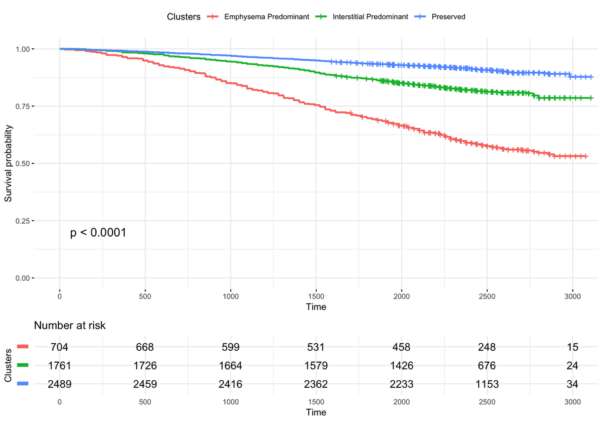

```r
# kaplan meier curve for mortality
km_fit <- survfit(Surv(days_followed, vital_status) ~ cluster_decamp, data=copd_full_imaging)
ggsurvplot(km_fit, data=copd_full_imaging,
           risk.table=TRUE,
           pval = TRUE,
           break.time.by = 500,
           ggtheme = theme_minimal(),
           risk.table.y.text.col = T,
           risk.table.y.text = FALSE,
           legend.title = "Clusters",
           legend.labs = c("Emphysema Predominant","Interstitial Predominant","Preserved"))
```